# Freby corperation

George.B

2022-12-17

# Summary

#### Project Problem.

- Which of the top 10 US companies has the Highest unit of share traded in th pass five years.

```
## # A tibble: 60 × 7
## # Groups:   Year [6]
##    Year  Company max_Open max_High max_Low max_Close max_Volume
##    <chr> <chr>      <dbl>    <dbl>   <dbl>     <dbl>      <dbl>
##  1 2017  AAPL        43.8     44.3    43.7      44.1  286856000
##  2 2017  AMZN        60.2     60.7    59.6      59.8  331300000
##  3 2017  GOOGL       53.8     53.9    53.2      53.9  103354000
##  4 2017  JP-MRGN    108.     108.    107.      108.    29350600
##  5 2017  M-SOFT      87.1     87.5    86.2      86.8   71066700
##  6 2017  NTFLX      202.     204.    198.      203.    23900100
##  7 2017  NVDA        54.3     54.7    53.7      54.2  168446000
##  8 2017  TSLA        76.1     77.9    75.5      77     98957000
##  9 2017  VISA       115.     115.    114.      114.    18909100
## 10 2017  WLMART      99.9    100.     99.1      99.6   38122400
## # … with 50 more rows
```

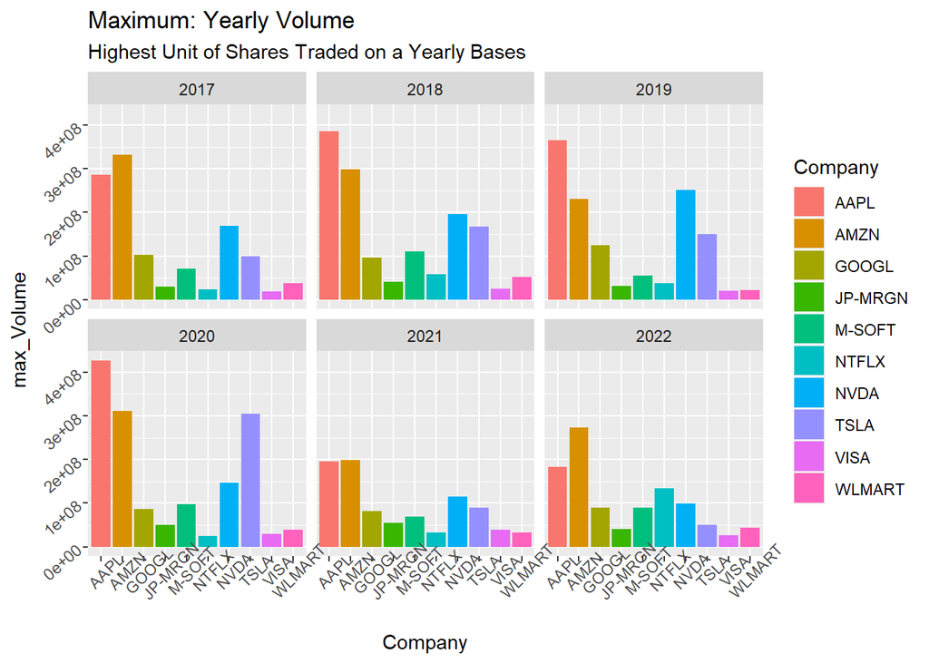

- The chart showcases the highest amount of volume traded the a single day in a year.
- Apple, Amazon and Nvidia has the highest amount of unit of share traded in the stock market.

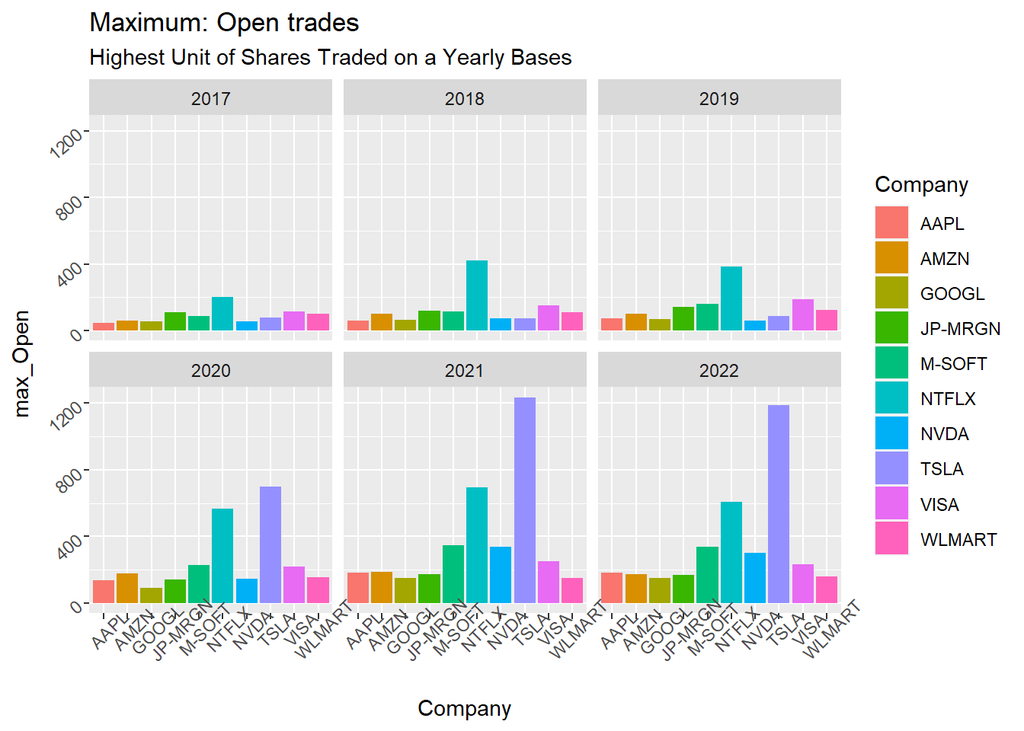

- The chart showcases the highest amount of Open trades the a single day in a year.
- Netflix and Tesla has the highest amount of Open trades in the stock market.

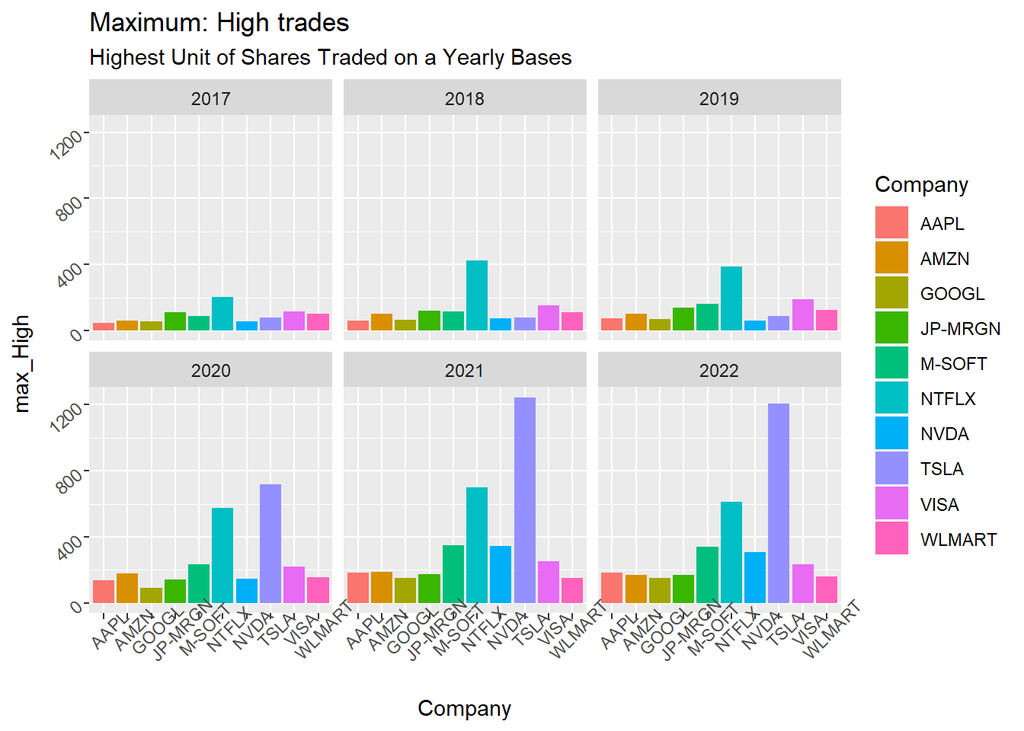

- The chart shows the amount of high trades a single unit of share cost in the market the a single day in a year.
- Netflix and Tesla still has the highest amount of high trades in the stock market.

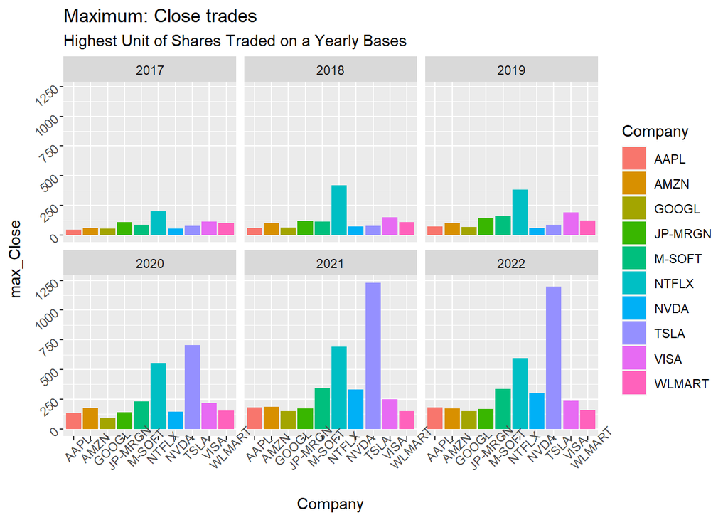

- The chart showcases the highest amount of Close trades a single unit of share was sold at, at the end of the working day in a year.
- Netflix and Tesla has the highest amount of Close trades in the stock market.

```
## # A tibble: 10 × 2
## # Groups:   Company [10]
##    Company total_volume_traded_yearly
##    <chr>                        <dbl>
##  1 AAPL                  150000000000
##  2 AMZN                  109000000000
##  3 GOOGL                  39126495100
##  4 JP-MRGN                18389163600
##  5 M-SOFT                 37266726500
##  6 NTFLX                   9917690000
##  7 NVDA                   60627875700
##  8 TSLA                   55442877900
##  9 VISA                   10635915200
## 10 WLMART                 10511356100
```

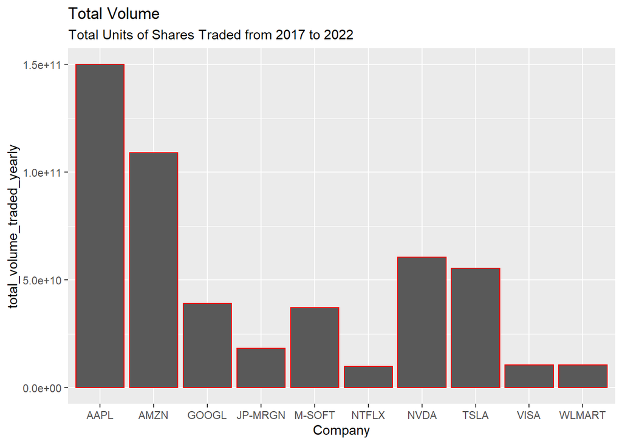

- The chart shows the total amount of Volume traded from 2017 to 2022 the the companies.
- Apple has the highest amount of unit of share traded in the market with an estimate of $150 billion shares traded in the 6 years, then followed by Amazon with an estimated share of over $109 billion shares traded from 2017 to 2022.

```
## # A tibble: 10 × 2
## # Groups:   Company [10]
##    Company total_volume_traded_yearly_dollar
##    <chr>                               <dbl>
##  1 AAPL                              1.24e13
##  2 AMZN                              1.22e13
##  3 GOOGL                             3.09e12
##  4 JP-MRGN                           2.03e12
##  5 M-SOFT                            6.64e12
##  6 NTFLX                             3.46e12
##  7 NVDA                              6.23e12
##  8 TSLA                              1.54e13
##  9 VISA                              1.85e12
## 10 WLMART                            1.19e12
```

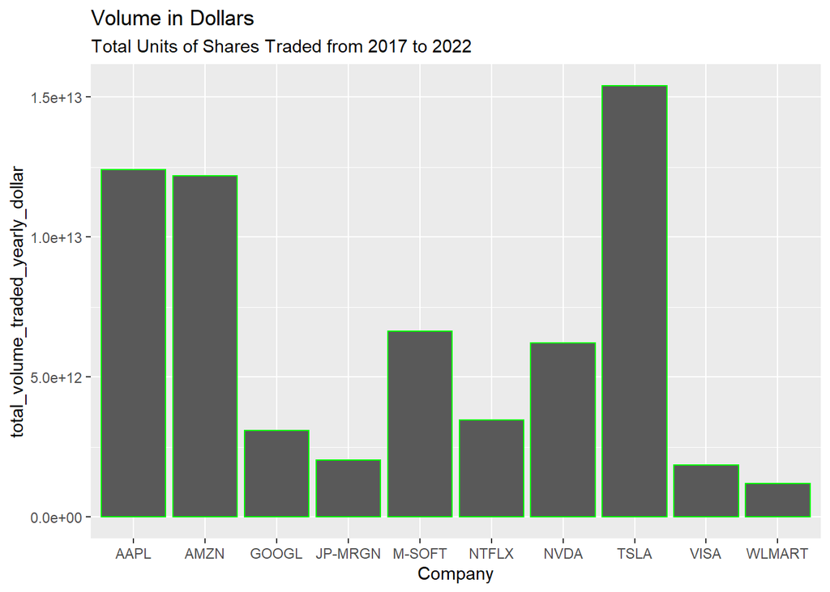

- The chart shows the total amount of Volume traded in Dollars from 2017 to 2022 the the companies.
- Tesla, Apple and Amazon has the highest amount of volume traded in Dollars which is as follows:-
- Tesla $15,400,000,000,000 from 2017 to 2022
- Apple $12,400,000,000,000 from 2017 to 2022
- Amazon $12,200,000,000,000 from 2017 to 2022.
- The amount in Dollar was gotten by multiplying Volume with Adj Close.